# Exploring the data

John Blischak

**Last updated:** 2015-10-21

**Code version:** 13dc5f39a87f3f771b0878782a960f23823f87ad

```r
library("knitr")
opts_chunk$set(fig.align = "center", fig.width = 10)
```

The data is ChIP-seq of H3K4me3 in yeast with the full length [Set1](http://www.ncbi.nlm.nih.gov/gene/856519) gene or a Set1 truncated to amino acids 762-1080. The truncated version is the carboxy terminus containing the [methyl transferase domain](http://www.ncbi.nlm.nih.gov/Structure/cdd/cddsrv.cgi?uid=214614).

## Setup

Load packages.

```r
library("tidyr")
library("dplyr")
library("edgeR")
library("ggplot2")
library("ggdendro")
library("cowplot")
theme_set(theme_bw(base_size = 12))
```

Create annotation file.

```r
files <- list.files("../../data/yeast/bed/", pattern = "promoter",
                    full.names = TRUE)
ip <- ifelse(grepl("H3K4ME3", files), "H3K4me3", "input")
set1 <- ifelse(grepl("Full_length", files), "full_length", "aa762_1080")
replicate <- ifelse(grepl("Rep_2", files), "r2", "r1")
sample <- paste(ip, set1, replicate, sep = ".")
anno <- data.frame(ip, set1, replicate, sample, stringsAsFactors = FALSE)
anno
```

```
##        ip        set1 replicate                 sample
## 1 H3K4me3  aa762_1080        r1  H3K4me3.aa762_1080.r1
## 2 H3K4me3  aa762_1080        r2  H3K4me3.aa762_1080.r2
## 3 H3K4me3 full_length        r1 H3K4me3.full_length.r1
## 4 H3K4me3 full_length        r2 H3K4me3.full_length.r2
## 5   input full_length        r1   input.full_length.r1
## 6   input  aa762_1080        r1    input.aa762_1080.r1
```

Add the total read counts from the various processing stages.

```r
mapped <- numeric(length = length(files))
unmapped <- numeric(length = length(files))
mapped_quality <- numeric(length = length(files))
non_duplicated <- numeric(length = length(files))
# mapped_promoters <- numeric(length = length(files))
path_bam <- "../../data/yeast/bam"
for (i in 1:length(files)) {
  base <- basename(files[i])
  base <- sub(".sorted.rmdup_promoter.bed", "", base)
  # print(base)
  mapped[i] <- scan(file.path(path_bam, paste0(base, "_mapped.txt")),
                    quiet = TRUE)
  unmapped[i] <- scan(file.path(path_bam, paste0(base, "_unmapped.txt")),
                    quiet = TRUE)
  mapped_quality[i] <- scan(file.path(path_bam, paste0(base, "_quality-mapped.txt")),
                    quiet = TRUE)
  non_duplicated[i] <- scan(file.path(path_bam, paste0(base, "_rmdup.txt")),
                    quiet = TRUE)
}
anno <- data.frame(anno, total = mapped + unmapped, mapped,
                   mapped_quality, non_duplicated,
                   stringsAsFactors = FALSE)
```

Save annotation file.

```r
write.table(anno, file = "../../data/yeast/annotation.txt", sep = "\t",
            quote = FALSE, row.names = FALSE)
```

Combine the bed files with counts of reads mapping to promoters.

```r
promoters <- read.table(files[1], sep = "\t", quote = "",
                        stringsAsFactors = FALSE)
colnames(promoters) <- c("chr", "start", "end", "name", "pos", "strand",
                         sample[1])
for (i in 2:length(files)) {
  tmp <- read.table(files[i], sep = "\t", quote = "", stringsAsFactors = FALSE)
  stopifnot(tmp$V4 == promoters$name)
  promoters <- cbind(promoters, tmp$V7)
  colnames(promoters)[ncol(promoters)] <- sample[i]
}
head(promoters)
```

```
##   chr start   end               name  pos strand H3K4me3.aa762_1080.r1
## 1   I 82250 82251 YAL034C;FUN19;1242 -300      -                    35
## 2   I 82249 82250 YAL034C;FUN19;1242 -299      -                    34
## 3   I 82248 82249 YAL034C;FUN19;1242 -298      -                    33
## 4   I 82247 82248 YAL034C;FUN19;1242 -297      -                    31
## 5   I 82246 82247 YAL034C;FUN19;1242 -296      -                    31
## 6   I 82245 82246 YAL034C;FUN19;1242 -295      -                    32
##   H3K4me3.aa762_1080.r2 H3K4me3.full_length.r1 H3K4me3.full_length.r2
## 1                    35                     29                     34
## 2                    34                     30                     33
## 3                    34                     29                     33
## 4                    34                     28                     33
## 5                    35                     27                     33
## 6                    37                     26                     32
##   input.full_length.r1 input.aa762_1080.r1
## 1                    5                   6
## 2                    5                   5
## 3                    6                   5
## 4                    6                   5
## 5                    6                   5
## 6                    6                   5
```

Separate the name column.

```r
promoters <- separate(promoters, col = name,
                      into = c("id", "gene", "gene_length"), sep = ";")
promoters$gene_length <- as.numeric(promoters$gene_length)
```

Save promoters file.

```r
write.table(promoters, file = "../../data/yeast/promoters.txt", sep = "\t",
            quote = FALSE, row.names = FALSE)
```

Calculate the reads per million using the total number of non-duplicated reads as the total count.

```r
promoters_rpm <- promoters
stopifnot(colnames(promoters_rpm)[9:14] == anno$sample)
for (i in 1:nrow(anno)) {
  promoters_rpm[, i + 8] <- promoters_rpm[, i + 8] / anno$non_duplicated[i] * 10^6
}
head(promoters_rpm)
```

```
##   chr start   end      id  gene gene_length  pos strand
## 1   I 82250 82251 YAL034C FUN19        1242 -300      -
## 2   I 82249 82250 YAL034C FUN19        1242 -299      -
## 3   I 82248 82249 YAL034C FUN19        1242 -298      -
## 4   I 82247 82248 YAL034C FUN19        1242 -297      -
## 5   I 82246 82247 YAL034C FUN19        1242 -296      -
## 6   I 82245 82246 YAL034C FUN19        1242 -295      -
##   H3K4me3.aa762_1080.r1 H3K4me3.aa762_1080.r2 H3K4me3.full_length.r1
## 1              17.07932              10.68612              10.919464
## 2              16.59134              10.38080              11.295997
## 3              16.10336              10.38080              10.919464
## 4              15.12740              10.38080              10.542931
## 5              15.12740              10.68612              10.166398
## 6              15.61538              11.29675               9.789864
##   H3K4me3.full_length.r2 input.full_length.r1 input.aa762_1080.r1
## 1               11.45383             2.396681            3.883151
## 2               11.11695             2.396681            3.235959
## 3               11.11695             2.876018            3.235959
## 4               11.11695             2.876018            3.235959
## 5               11.11695             2.876018            3.235959
## 6               10.78008             2.876018            3.235959
```

## Total counts

Compare the total counts between samples across the processing stages.

| Stage | Description |
| --- | --- |
| total | Full sequecing depth |
| mapped | reads mapped to yeast genome |
| mapped_quality | reads with bwa mapping quality > 10 |
| non_duplicated | Duplicates removed with `samtools rmdup` |

```r
head(anno)
```

```
##        ip        set1 replicate                 sample   total  mapped
## 1 H3K4me3  aa762_1080        r1  H3K4me3.aa762_1080.r1 2996627 2780365
## 2 H3K4me3  aa762_1080        r2  H3K4me3.aa762_1080.r2 4670790 4212929
## 3 H3K4me3 full_length        r1 H3K4me3.full_length.r1 3931575 3605503
## 4 H3K4me3 full_length        r2 H3K4me3.full_length.r2 4658812 3818560
## 5   input full_length        r1   input.full_length.r1 3349887 2987036
## 6   input  aa762_1080        r1    input.aa762_1080.r1 2858605 2371804
##   mapped_quality non_duplicated
## 1        2490980        2049262
## 2        4018319        3275278
## 3        3338564        2655808
## 4        3661907        2968439
## 5        2556573        2086218
## 6        2012377        1545137
```

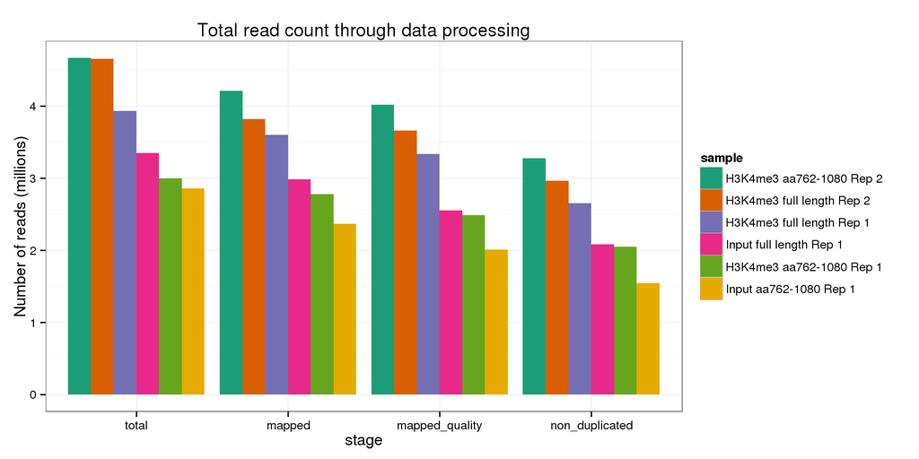

```r
anno_long <- gather(anno, key = "stage", value = "count", total:non_duplicated)
anno_long$stage <- factor(anno_long$stage,
                          levels = c("total", "mapped", "mapped_quality",
                                     "non_duplicated"))
anno_long$sample <- factor(anno_long$sample,
                           levels = anno$sample[order(anno$total,
                                                      decreasing = TRUE)],
                           labels = c("H3K4me3 aa762-1080 Rep 1",
                                      "H3K4me3 aa762-1080 Rep 2",
                                      "H3K4me3 full length Rep 1",
                                      "H3K4me3 full length Rep 2",
                                      "Input full length Rep 1",
                                      "Input aa762-1080 Rep 1")[order(anno$total,
                                                                decreasing = TRUE)])
anno_long$count <- anno_long$count / 10^6
ggplot(anno_long, aes(x = stage, y = count, fill = sample)) +
  geom_bar(stat = "identity", position = "dodge") +
  scale_fill_brewer(palette = "Dark2") +
  labs(title = "Total read count through data processing",
       y = "Number of reads (millions)")
```

## Comparing IP to input

Caclulate the mean and standard error of the mean (sem) of the reads per million (rpm) for each base 300 bp upstream of the TSS to 300 bp downstream of the TSS across all the genes.

```r
promoters_rpm_long <- gather(promoters_rpm, key = "experiment", value = "rpm",
                             H3K4me3.aa762_1080.r1:input.aa762_1080.r1)
num_genes <- length(unique(promoters$gene))
meta_gene <- promoters_rpm_long %>%
  group_by(experiment, pos) %>%
  summarize(mean = mean(rpm), sem = sd(rpm) / sqrt(num_genes))
meta_gene$experiment <- factor(meta_gene$experiment,
                               levels = c("H3K4me3.full_length.r1",
                                          "H3K4me3.full_length.r2",
                                          "H3K4me3.aa762_1080.r1",
                                          "H3K4me3.aa762_1080.r2",
                                          "input.full_length.r1",
                                          "input.aa762_1080.r1"),
                               labels = c("H3K4me3 full length Rep 1",
                                          "H3K4me3 full length Rep 2",
                                          "H3K4me3 aa762-1080 Rep 1",
                                          "H3K4me3 aa762-1080 Rep 2",
                                          "Input full length Rep 1",
                                          "Input aa762-1080 Rep 1"))
```

This is based on 4460 genes which had a transcript length greater than 500 bp (actual minimum length is 501 bp).

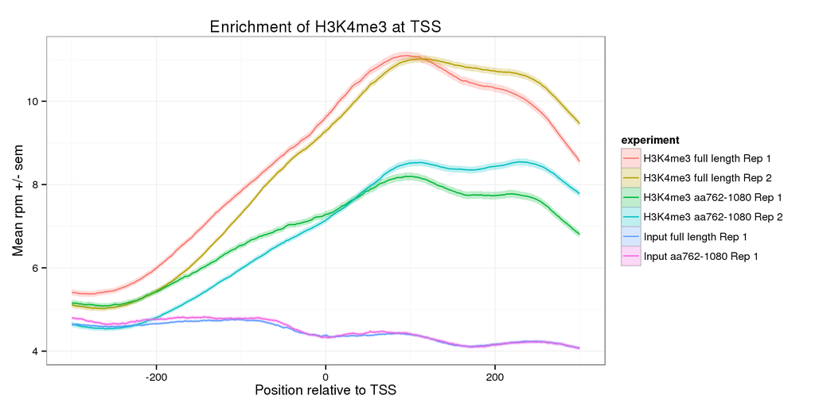

```r
ggplot(meta_gene, aes(x = pos, y = mean)) +
  geom_line(aes(color = experiment)) +
  geom_ribbon(aes(ymin = mean - sem, ymax = mean + sem, fill = experiment),
              alpha = 0.25) +
  labs(x = "Position relative to TSS", y = "Mean rpm +/- sem",
       title = "Enrichment of H3K4me3 at TSS")
```

The H3K4me3 enrichment is the strongest for the yeast with a full length Set 1, intermediate for the yeast with truncated Set1, and low for both input samples.